# Installing, Loading and Updating Packages

2023 Bio R Workshop

Author

**Prof. Rey R. Cuenca**  
*Math-Stat Dept., MSU-IIT*

## Installing Packages

We now install the necessary package we need for this workshop called `tidyverse`. There are two ways we can do this:

1. Go to the console pane, type the following code and hit Enter.

   ```r
   install.packages("tidyverse")
   ```

[figure not shown]

2. Alternatively, one go to `Tools > Install Packages` and type on `Packages` blank entry the name of the package you want to install, e.g. `tidyverse`. Once done click “Install”.

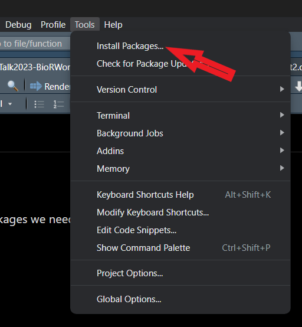

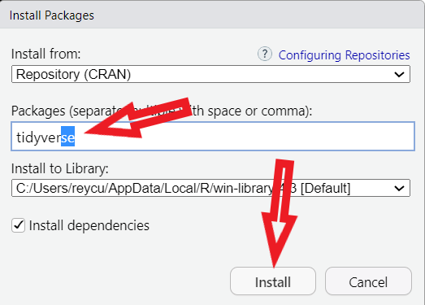

   Figure 1: Installing packages using RStudio’s Tools menu.

## Loading Packages

There are two ways to load a package in a current session of R.

1. Using the Console, type the following command line and hit Enter.

   ```r
   library(tidyverse)
   ```

2. Using `Packages` tab in the `Output Pane`, first search the name of the package (assuming it is already installed) in the mini-search bar. Check the corresponding check box that matches to the package you want to load in the current session of R.

[figure not shown]

When you installed R for the first time in you system, some packages are already pre-installed along with it. Some of these packages are even pre-loaded when you open RStudio:

[figure not shown]

## Updating Packages

To check for updates on all currently installed packages,

1. Go to `Tools > Check for Package Updates`:

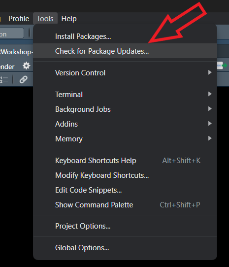

2. Check the boxes of all packages you want to update and click “Install”.

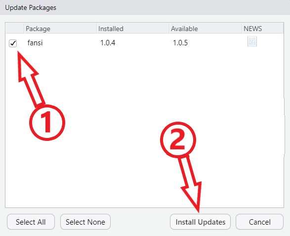

3. Sometimes you are prompted to restart you current session if some packages are pre-loaded that needs to updated simultaneously with the package we want to update. Just click “Yes”. (**Note:** If this problem still persists, just close the current project and do steps 1 and 2 again.) Moreover, there is also the case when updating a package gives you an option on whether to compile from source or not. Usually, we just click “Yes” on this.

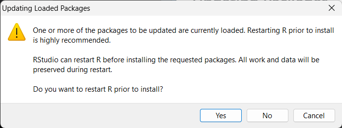

   (a) Prompt to Restart

[figure not shown]

   (b) Compile from Source

   Figure 2: Other possible scenarios during updating of packages.

4. The last step is to wait for the installation to finish and then you are done.

[figure not shown]